# O que dizem as agressões a jornalistas no período eleitoral?

por Felipe Giacomelli

Após compilados, [os dados foram disponibilizados online](https://docs.google.com/spreadsheets/d/1fP6owOQTOT4bdgCrCbDz9piYkAk6QEPtOofvmJ2EYMs/edit#gid=1508221017).

Mas o que significa um caso de agressão a jornalistas? Segundo a Abraji, entra desde tiros disparados na direção de profissionais da imprensa a ofensas pela internet.

Com base nos dados divulgados, o método mais comum foi o de exposição indevida, quando o agressor compartilha o perfil do jornalista em uma rede social e incentiva que seus seguidores o ataquem. Ao todo, foram 56 casos assim.

Um profissional pode sofrer violência de mais de uma forma em um mesmo episódio. Por exemplo, pode ser hostilizado verbalmente e agredido fisicamente por uma mesma pessoa. Assim, ao dividir as ocorrências por método, o total supera os mais de 130 jornalistas vítimas de violência no compilado pela Abraji.

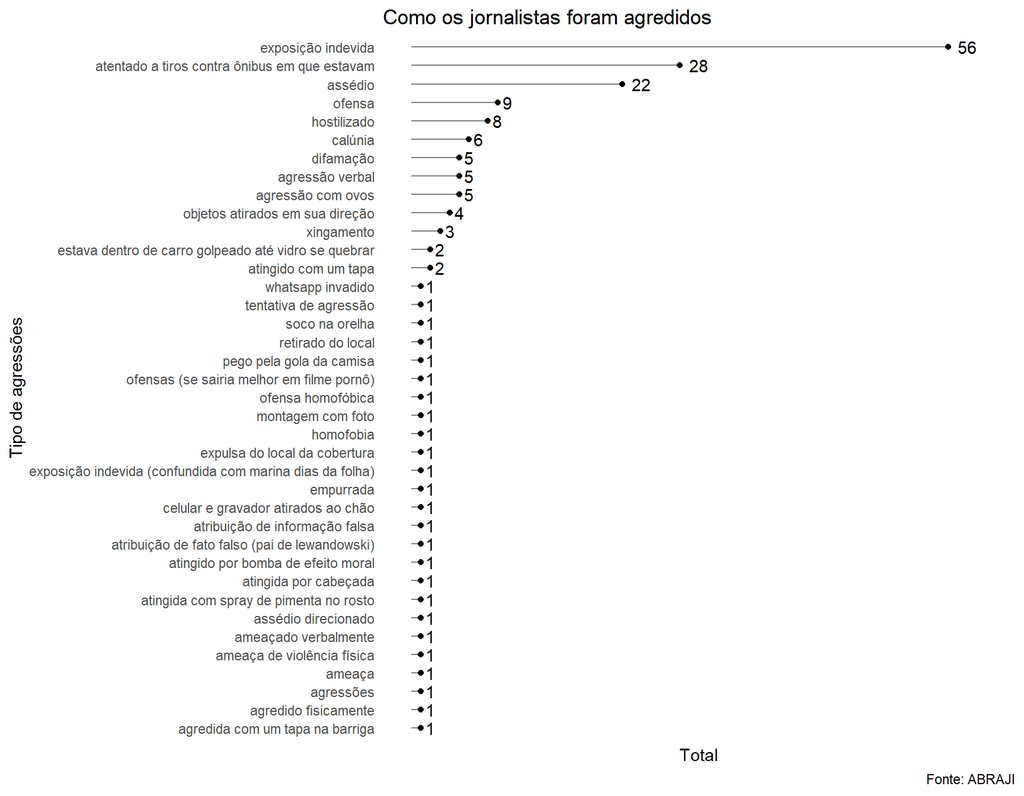

Apesar de o levantamento traçar um panorama desde o começo do ano, conforme o primeiro turno da eleição foi se aproximando, os casos de violência se tornaram mais comuns. No entanto, foram dois episódios no primeiro semestre que tiveram o maior número de jornalistas agredidos.

O primeiro aconteceu em 27 de março, quando dois ônibus com profissionais da imprensa, que acompanhavam uma caravana organizada pelo ex-presidente Luiz Inácio Lula da Silva (PT), foram acertados por tiros. Ninguém saiu ferido. Pela metodologia aplicada pela Abraji, cada repórter que estava nos veículos representa uma ocorrência distinta. Assim, 28 foram registradas no episódio.

O segundo teve início em 10 de maio quando o Facebook fechou uma parceria com agências de checagem de informação para tentar combater as fake news no período eleitoral.

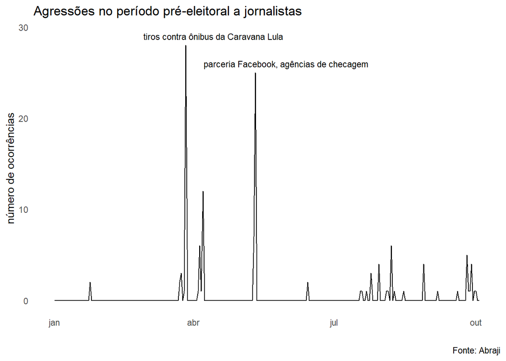

O caso do pedido de prisão do ex-presidente Lula e a entrevista do candidato à presidência Jair Bolsonaro (PSL) à Globonews, em agosto, também tiveram número elevado de ocorrências.

|  | motivo | total |
| --- | --- | --- |
| 1 | Cobertura da caravana de Lula pelo Sul do país | 33 |
| 2 | Parceria de agências de checagem com Facebook | 32 |
| 3 | Pós pedido de prisão de Lula | 19 |
| 4 | Entrevista de Jair Bolsonaro na GloboNews | 7 |
| 5 | Reportagem sobre ameaça de Bolsonaro a ex-mulher | 6 |
| 6 | Entrevista de Jair Bolsonaro ao Roda Viva | 4 |
| 7 | Derrubada de páginas ligadas a MBL pelo Facebook | 3 |
| 8 | Reportagem sobre processo de separação de Bolsonaro | 3 |
| 9 | Checagens sobre entrega de terço a Lula | 2 |
| 10 | Cobertura de julgamento de Lula no TRF-4 | 2 |

[output cut: 17 more lines]

Falando em fake news, além de a iniciativa da rede social para tentar diminuir o número de informações falsas circulando em suas páginas ter sido um dos episódios com mais agressões registradas, os profissionais da Agência Pública e da Lupa, ambas de checagem, lideraram o ranking de ocorrências por empresas.

Veículos tradicionais, como Globonews, “O Globo”, “Folha de S.Paulo” e “Veja” também tiveram seus profissionais entre os mais hostilizados.

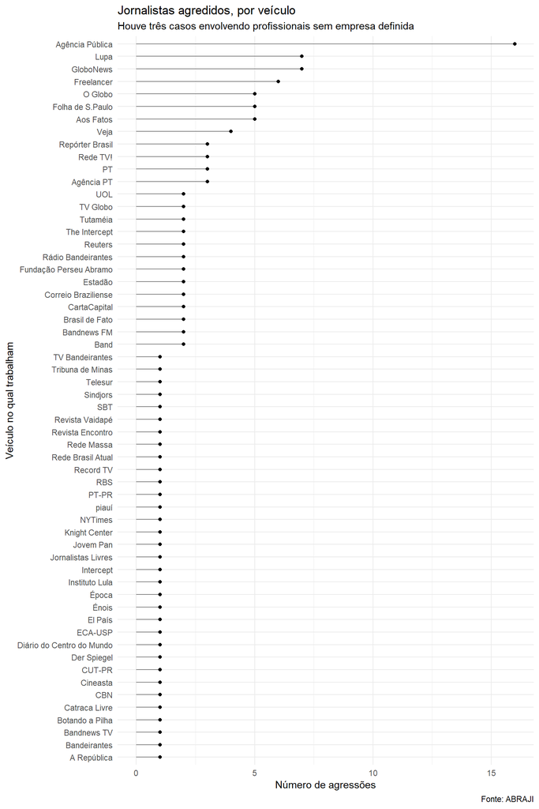

Fazendo uma divisão por Estado, as agressões à imprensa aconteceram principalmente no Paraná e no Rio de Janeiro. O primeiro está ligado à metodologia de considerar cada jornalista nos ônibus da caravana como uma ocorrência diferente.

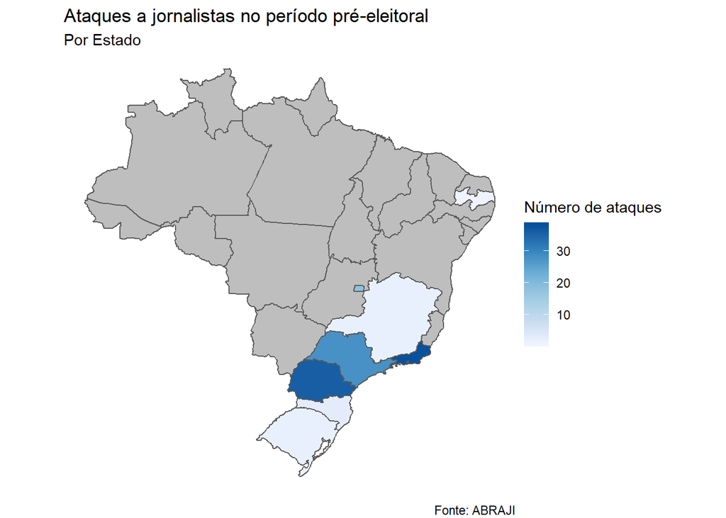